# UAGMS User Guide

Lubomir Botev

20/08/2019

The User guide below is composed of 3 principal components: the FAQ, the Detailed Feature Description and the Workflow guide.

# FAQ

## Can I use my own data instead of the preloaded database (default)?

You can upload your own datasource by navigating to the ‘Data Configuration Tab’ on the left hand side, and uploading it in a .csv format. You can choose individual files for Entry/Exit Shrinkage.

It must be formated with column names in the first row, and the first column must contain the date in the format “%d/%m/%Y”, as seen below. You can then use the app as normal.

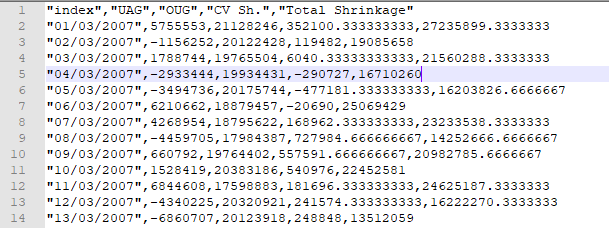

Note: Uploading custom .csv for entry or exit will disable some of the relational functionality.

## How can I download the results of my analysis

There are 2 pathways to follow when you want to download results. The reporting tab allows you to select modules to include in a report, and then runs the analysis using the options selected in-app and collates this in a .pdf format.

The results of a batch analysis of an interval of individual days (returning the flagged nodes for each) can be downloaded in the Day Explorer. Note that you need to select the range in the UAG monitor tab.

## The changepoint analysis looks supsicious - I expect to find some changes in my data!

Whilst the changepoint models use default statistically sound parameters for the significance testing, scenarios may arise where an estimate of a known change is required; this can be achieved by lowering the significance thresholds. Whilst these differe according to algorithm, these controls have been provided in the form of sliders in the changepoint tab. As we canot specify a required number of changepoints when using the PELT procedure, you must select ‘BinSeg’ to be able to change the significance levels for that algorithm.

# Feature documentation

In the below sections, every input and output is identified and its use explained, along with general instructions on the use and functionality of each tab.

## UAG Baseline

The UAG Baseline tab’s purpose is to review various baseline models, and using these identify Gas Days where the UAG exceed the upper or lower permissible bounds. Different models have different parameters (i.e. , calibration). It is recommended a mixture of models is used when assesing whether to proceed with an investigation. Each model, and their parameters is decribed below.

### Models

1. **Bollinger Bands:** These are rolling n-day standard deviation intervals. Default parameters are 30 days and 2 standard deviations. This is a basic but powerful model, suitable for identifying large and medium sized errors. However, it will normalise around the 30-day trend so may be unreliable if multiple large errors occur within the same time interval.
2. **Fixed Limit:** Fixed, straight line limits. Negative and positive parameters can be set independantly. Default: 20,-20
3. **Percentage Throughput:** Limits calculated as a percentage (Default: 3%) of total system throughput. May be innacurate if custom data is used, which does not reflect the total input/outputs. The calculation can be done wither using the supply or demand side (Default:Supply)
4. **D’Arpino:** Limits calculated as per Arpino et al, 2014. (Unaccounted for gas in natural gas transmission networks: Prediction model and analysis of the solutions). Parameter: R, multiplicative coefficient defaults to 0.15 (unimplemented)
5. **Anomalise:** Limits calclulated as point anomalies following a time series decomposition, using the IQR method (Reference). Note no confidence interval can be shown from this model.
6. **ETS:** A Univariate xponential smoothing state space model time series model is automatically fitted, and x% intervals are calculated. These default to 95 %

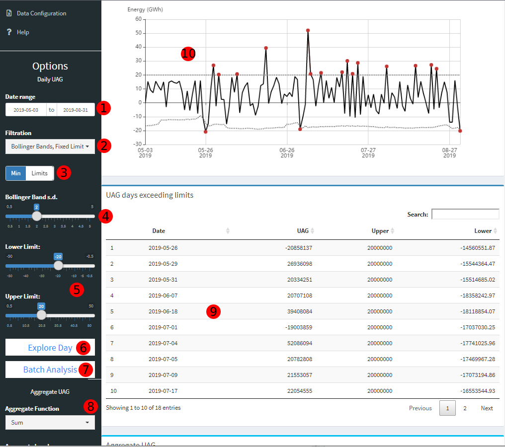

Baseline UAG

1. Date selector: Chose the range across which you want to both perform analysis and visualise.
2. Filters: Chose what models to use when calculating UAG boundaries
3. Min/Max Limit Selector: Determines whether upper and lower bounds are aggregated across models by taking the minimum or maximum, respectively - thie equates to a best or worst case scenario. If you want to view individual bounds, you can select only a single filter.
4. Filter Options: Bollinger band Standard deviation: This controls the width of the Bollinger Bands. Increasing this value will make the intervals wider, and vice versa.
5. Fixed limit upper and lower boundary control sliders. Note: Other filters may have additional options available.
6. Explore day: Pressing this button when you have a day selected in Table 9 will take you to the causality Analysis tab, with a basic analysis being calculated immediately.
7. Batch nalysis: This conducts an analysis on all days exceeding the baseline. The analysis options need to be determined in the causality analysis a priori.
8. Aggregate Function and Aggregate level: Allows you to switch between aggregation functions (Sum or Abs Sum) and levels (Weekly, Quarterly etc) for the Aggregate UAG high-level view.
9. Table: Days exceeding the specified baseline and tabulated here. This table is interactive - you can click on a day for it to be highlighted on chart 10.
10. Chart: A visual representation of UAG along with baseline lower and upper limits for the selected timeframe. Clicking on a day (red dot) will automatically highlight this in table 9.

## Changepoint Analysis

This tab allows you to search for changes in the trend component of the UAG. Whilst no sites can be narrowed down, this should give you an indication whether or not a fault exists in the system. Calibration options are available on the left hand side. Consulting a number of models to determine a changepoint can be considered best practice.

[figure not shown]

1. Changepoint method to use in graph 7 and table 8. PELT does not allow for a sensitivity control, whilst BinSeg does.
2. Maximum number of changepoint in a BinSeg model.
3. BCP sensitivity selector
4. Cumulative sum standard deviation decision boundary : The number of standard deviations that must be exceeded in order to identify a changepoint
5. BCP graph output. Changepoint present themselves as spikes in the conditional probablitity. A Flat profile indicates no changepoints.
6. CUSUM output: A sustained shift past the decision boundary represents a changepoint. This should not be used to identify more than one changepoint.
7. PELT/BingSeg output - changepoint are clearly identified in this graph.
8. Summary output from Model depicted in graph 7. Exact Changepoint dates are identified in this graph.

## Causality Analysis

This tab allows you to narrow down sites for further inspection, on any given day. You may select what flags to search for on the left hand side; Note that due to the computational complexity, this is not immediately calculated, and will be evaluated only when the calculate button is pressed. Past analyses may be accessed frop the Analyis dropdown. A .csv output of the table can also be downloaded.

[figure not shown]

1. Flag selector - see Flags
2. Date selector - this is automatically set as the date selected in UAG Baseline, but you may chose any date.
3. Calculate Button - this starts the analyis.
4. Past analysis - select one to change output
5. Download analysis - outputs table in a csv format
6. Inspect offtake - Takes you to LDZ Models, with the site name and date already pre-selected.
7. Interactive Time-series view for selected site
8. Map, site location
9. Node list - select a node here to display it in graph 7. Any identified flag will also come up.
10. Statistics : Statistics useful to an investigator.

### Flags

1. Interrupts: Locates nodes with the following flow pattern: D-1: >0 / D:0 0 / D+1 >0. This can indicate missing data
2. Fast anomaly detection: Uses stl decomposition followed by using the iqr outlier detection method on residuals
3. Quantile: Identifies values lower than the 2/% or greater than the /98% quantile - flags are return as either High or Low
4. Percentage Change: Can be used to identify nodes with a significant increase or decrease
5. Extreme: Abnormal or max/min data
6. Slow anomaly detection: GESD method
7. LDZ LM: Linear models fitted only to NTS offtakes

## LDZ Models

This Tab allows you to acces contextual visualisation and model output when dealing with NTS Offtake. These sites can be moddeled succesfully with linear models, and these models can be explored in this tab, alongside an overview of an LDZ on a given day

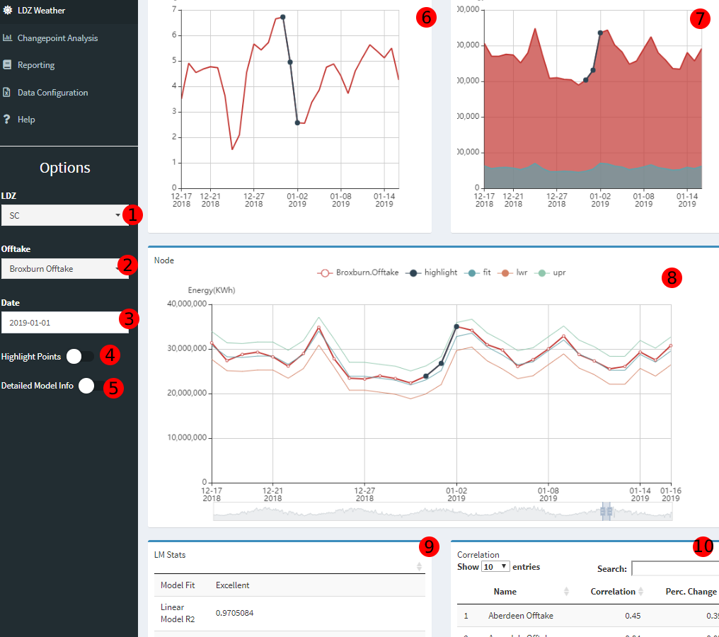

1. LDZ selector - This can independently change the Aggregate and Weather outputs (6,7)
2. Site selector - Selecting a site will automaticallly also update (6,7) with the corresponding LDZ.
3. Date selector - Select date to focus on / highlight
4. Additional highlights for selected date on graphs (6,7,8)
5. Display diagnostic model info in box 9
6. Cumulative weather variable for LDZ, from MIPI
7. Aggregate LDZ vs site flow
8. Model 95% prediction intervals
9. Model info
10. Correlation vs Percentage change table for LDZ.

## Data Configuration

The data configuration tab allows the user to select the data source independantly for the following databases: Entry, Exit and Shrinkage. Entry and Exit include all nodes in either side of the gas equation; Shrinkage includes primarily the UAG. Defaults are databases sources from the NH website and API (MIPI) - these are updated manually. A warning will inform the user on startup if the database is outdated.

Custom data may be uploaded in place of the onine DB in a .csv format for each of these components. Headers are required, with Date being the first column in the format dd/mm/yyyy. This format MUST be followed to succesfully parse the database. You will not be allowed to shift out of this tab until a workable configuration is selected.

Note that uploading custom entry/exit data will disable numerous features which rely on relational databases which cannot be utilised for custom data.

[figure not shown]

1. Data Summary Table: Affirms data source and displays Start / End dates for active DB’s. Also displays the maximum joint timeframe, which is the period over which all analysis features are enabled.
2. Synchronisation Dates: Displays last good sync date for each of the components
3. Shrinkage SourceL Default: Online. Deselect to acces contextual upload menu.
4. Entry Source. Default : MIPI. Deselect to acces contextual upload menu.
5. Exit Source. Default : MIPI. Deselect to acces contextual upload menu.

## Reporting

In the reporting tab, much of the interactive analysis available within the app can be exported in a hard copy format - .pdf. Furthermore, the internal databases of the app can also be downloaded from here.

[figure not shown]

### Report Components

1. Daily Balancing Errors : detailed output from the UAG balancing tab: individual model upper limits are extracted
2. Changepoints : Identical output to the changepoint tab
3. Historic Performance [undeployed]
4. Flow vis [undeployed]

# Workflow Examples

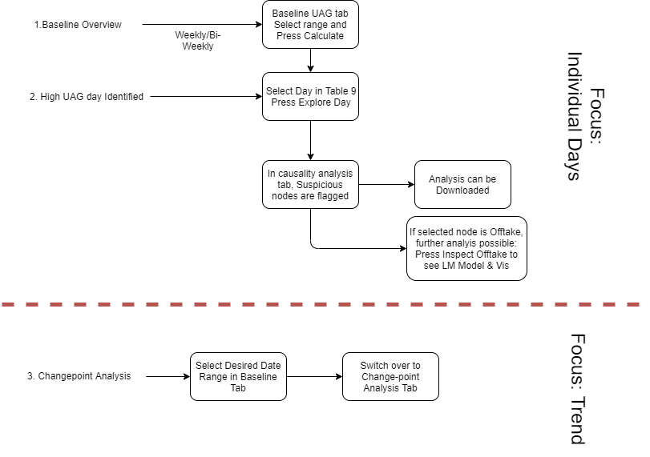

Workflow Example